# Residuals and residual variation

Brian Caffo, Jeff Leek and Roger Peng

## Residuals

- Model $Y_i = \beta_0 + \beta_1 X_i + \epsilon_i$ where $\epsilon_i \sim N(0, \sigma^2)$.
- Observed outcome $i$ is $Y_i$ at predictor value $X_i$
- Predicted outcome $i$ is $\hat Y_i$ at predictor valuve $X_i$ is $\hat Y_i = \hat \beta_0 + \hat \beta_1 X_i$
- Residual, the between the observed and predicted outcome $e_i = Y_i - \hat Y_i$
- The vertical distance between the observed data point and the regression line
- Least squares minimizes $\sum_{i=1}^n e_i^2$
- The $e_i$ can be thought of as estimates of the $\epsilon_i$.

## Code

```r
data(diamond)
y <- diamond$price; x <- diamond$carat; n <- length(y)
fit <- lm(y ~ x)
e <- resid(fit)
yhat <- predict(fit)
max(abs(e -(y - yhat)))
```

```
[1] 9.486e-13
```

```r
max(abs(e - (y - coef(fit)[1] - coef(fit)[2] * x)))
```

```
[1] 9.486e-13
```

## Residuals versus X

[figure not shown]

[figure not shown]

```r
plot(x, resid(lm(y ~ x)));
abline(h = 0)
```

## Getting rid of the blank space can be helpful

[figure not shown]

```r
plot(x, resid(lm(y ~ x)));
abline(h = 0)
```

## Diamond example

```r
y <- diamond$price; x <- diamond$carat; n <- length(y)
fit <- lm(y ~ x)
summary(fit)$sigma
```

```
[1] 31.84
```

```r
sqrt(sum(resid(fit)^2) / (n - 2))
```

```
[1] 31.84
```

## Summarizing variation

$\sum_{i=1}^n (Y_i - \bar Y)^2 = \sum_{i=1}^n (Y_i - \hat Y_i)^2 + \sum_{i=1}^n (\hat Y_i - \bar Y)^2$

Or

Total Variation = Residual Variation + Regression Variation

Define the percent of total varation described by the model as $R^2 = \frac{\sum_{i=1}^n (\hat Y_i - \bar Y)^2}{\sum_{i=1}^n (Y_i - \bar Y)^2} = 1 - \frac{\sum_{i=1}^n (Y_i - \hat Y_i)^2}{\sum_{i=1}^n (Y_i - \bar Y)^2}$

## Some facts about $R^2$

- $R^2$ is the percentage of variation explained by the regression model.
- $0 \leq R^2 \leq 1$
- $R^2$ is the sample correlation squared.
- $R^2$ can be a misleading summary of model fit.
- Deleting data can inflate $R^2$.
- (For later.) Adding terms to a regression model always increases $R^2$.
- Do `example(anscombe)` to see the following data.
- Basically same mean and variance of X and Y.
- Identical correlations (hence same $R^2$ ).
- Same linear regression relationship.

## `data(anscombe);example(anscombe)`

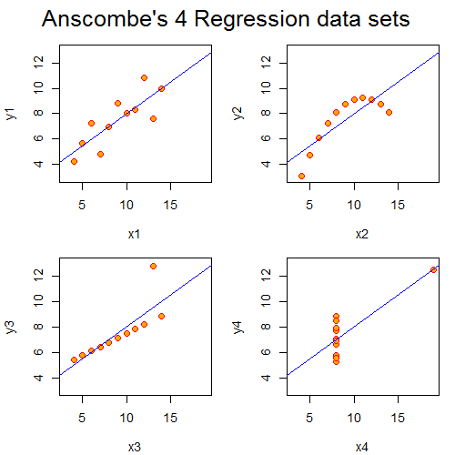